# Clinical Data Analysis

ChangShen

10/31/2019

## Data Description

After the database connecting, reformating and creating new summary variable by unique ID(patient), we get a finaldata includes the personal information, past diagnose(both in and out hospital) and prescription recording.

#### FINALDATA have 5871 obeservations and 12 variables

- **uniqueID** - patient ID unique for each patient
- **Sex** - gender for each patient
- **Birthdate**- Birthdat of each patient with format(mm/dd/yyyy)
- **race** - race of paitients including Asian/Black/Native American/Pacific Islander/Unknown/White
- **martital_status** - martital_status of patients(Divorced/Married/Other/Separated/Single/Widowed)
- **income_braket** - income of patients (<20,000/> 120,000/20,000 to <40,000/40,000 to <80,000/80,000 to 120,000/Missing/Refuse to Respond)
- **Age** - age of patient(round to 2 decimals)
- **Agecat** - age category(younger/older)
- **A1** - Indicator of whether an individual has chronic condition A1 prior to 2015
- **DiseaseX** - Indicator of whether an individual has been diagnosed with disease X
- **WE_indicator** - Indicator of receipt of prescription WE any time during 2015 and 2016 for those with chronic condition A1 prior to 2015 (A1 created above)
- **WE_6_M** - Indicator of receipt of WE longer than 6 months.

#### 0

We can see the detail of the final data(head&tail) as follows.

First 5 observations of the FINALDATA

| uniqueID | sex | BirthDate | race | marital_status | income_bracket | Age | Agecat | A1 | WE_indicator | WE_6_M | DiseaseX |
| --- | --- | --- | --- | --- | --- | --- | --- | --- | --- | --- | --- |
| 1000086 | Male | 10/13/1947 | Black | Married | 20,000 to <40,000 | 50.91 | older | 0 | 0 | 0 | 1 |
| 1000189 | Male | 11/28/1954 | White | Divorced | 80,000 to 120,000 | 59.71 | older | 0 | 0 | 0 | 1 |
| 1002653 | Male | 01/13/1969 | Black | Divorced | Missing | 35.79 | younger | 0 | 0 | 0 | 0 |
| 1003091 | Male | 06/19/1961 | Native American | Married | 80,000 to 120,000 | 39.15 | younger | 0 | 0 | 0 | 1 |
| 1004796 | Male | 09/14/1957 | White | Married | > 120,000 | 46.84 | younger | 1 | 0 | 0 | 0 |

Last 5 observations of the FINALDATA

|  | uniqueID | sex | BirthDate | race | marital_status | income_bracket | Age | Agecat | A1 | WE_indicator | WE_6_M | DiseaseX |
| --- | --- | --- | --- | --- | --- | --- | --- | --- | --- | --- | --- | --- |
| 5867 | 9987005 | Male | 02/22/1951 | Asian | Single | 40,000 to <80,000 | 57.68 | older | 0 | 0 | 0 | 1 |
| 5868 | 9987534 | Male | 02/06/1932 | Unknown | Divorced | 20,000 to <40,000 | 83.88 | older | 0 | 0 | 0 | 0 |
| 5869 | 9993792 | Male | 11/25/1948 | White | Widowed | 20,000 to <40,000 | 65.50 | older | 0 | 0 | 0 | 1 |
| 5870 | 9998976 | Male | 06/24/1956 | White | Separated | Refuse to Respond | 59.27 | older | 1 | 0 | 0 | 1 |
| 5871 | 9999216 | Male | 12/25/1948 | White | Single | Refuse to Respond | 65.49 | older | 1 | 0 | 0 | 1 |

#### A

A table with the frequency distribution of sex in FINALDATA

| sex | freqency |
| --- | --- |
| Female | 287 |
| Male | 5584 |

A table with the frequency distribution of race in FINALDATA

| race | freqency |
| --- | --- |
| Asian | 333 |
| Black | 1530 |
| Native American | 318 |
| Pacific Islander | 341 |
| Unknown | 855 |
| White | 2494 |

A table with the frequency distribution of marital_status in FINALDATA

| marital status | freqency |
| --- | --- |
| Divorced | 1168 |
| Married | 2451 |
| Other | 358 |
| Separated | 611 |
| Single | 641 |
| Widowed | 642 |

A table with the frequency distribution of income_bracket in FINALDATA

| income bracket | freqency |
| --- | --- |
| <20,000 | 1443 |
| > 120,000 | 324 |
| 20,000 to <40,000 | 1426 |
| 40,000 to <80,000 | 863 |
| 80,000 to 120,000 | 603 |
| Missing | 587 |
| Refuse to Respond | 625 |

A table with the frequency distribution of Agecat in FINALDATA

| age category | freqency |
| --- | --- |
| older | 3542 |
| younger | 2329 |

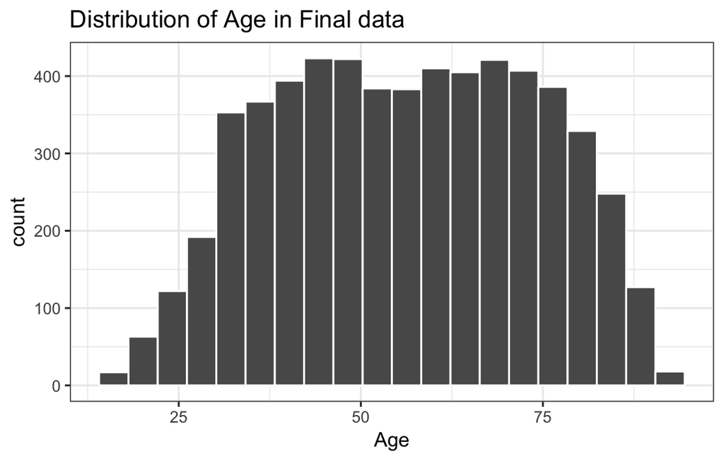

#### B

The proportion of individuals in the cohort had chronic condition A1 prior to 2015 is 33.09 %.

#### C

age distribution of chronic condition A1 in this population

|  | older | younger |
| --- | --- | --- |
| No chronic condition A1 | 2288 | 1640 |
| chronic condition A1 | 1254 | 689 |

#### D

proportion of individuals have disease X is 66.16 %.

#### E

gender distribution of disease X in the population

|  | Female | Male |
| --- | --- | --- |
| No DiseaseX | 91 | 1896 |
| Have DiseaseX | 196 | 3688 |

#### F

The proportion of individuals classified as having chronic condition A1 prior to 2015,received a prescription for WE (medication name) during the 2015 and 2016 calendar years is 53.83 %.

#### G

the breakdown by race of individuals classified as having chronic condition A1 prior to 2015 and received a prescription for WE (medication name) during the 2015 and 2016 calendar years

[output not shown]

#### H

proportion of individuals classified as having chronic condition A1 prior to 2015 receiving a prescription for WE (medication name) during the 2015 and 2016 calendar years would be covered longer than 6-month over this time frame is 29.18 %.